# Enfoque Estadístico del Aprendizaje, primer Trabajo Práctico

## Limpieza de datos

Vamos a comenzar rápidamente eliminando la variable bedrooms, la cual recordemos que tenía una cantidad considerablemente grande de outliers y estaba muy correlacionada a rooms, por lo que si usamos solamente rooms en nuestro modelo no deberíamos perder demasiado.

```r
datos_sin_bed <- datos_seleccion %>%
  select(-bedrooms)
```

Procedemos a eliminar los faltantes de las otras variables (https://www.edureka.co/community/634/how-to-remove-na-values-with-dplyr-filter).

```r
datos_sin_faltantes <- datos_sin_bed %>%
  drop_na()
```

Por último, quitamos las observaciones que cumplan surface_total < surface_covered, ya que una propiedad no puede cubrir más superficie que la del terreno a la que está restringida.

```r
datos_limpios <- datos_sin_faltantes %>%
  filter((surface_total < surface_covered) == FALSE)
```

Veamos como quedó nuestro dataset tras realizar esta limpieza

```r
glimpse(datos_limpios)
```

```
Rows: 50,828
Columns: 8
$ id              <fct> AfdcsqUSelai1ofCAq2B0Q==, ESzybdH7YU2uIU1/kHtRGw==, r22OfzZ3kXooSPoE5HMuZQ==, atZQXVty…
$ l3              <fct> Velez Sarsfield, Nuñez, Almagro, Almagro, Almagro, Almagro, Almagro, Almagro, Almagro,…
$ rooms           <int> 3, 1, 1, 1, 1, 1, 1, 1, 1, 1, 1, 1, 1, 1, 1, 3, 1, 1, 2, 1, 1, 1, 1, 1, 4, 1, 2, 1, 1,…
$ bathrooms       <int> 2, 1, 1, 1, 1, 1, 1, 1, 1, 1, 1, 1, 1, 1, 1, 2, 1, 1, 1, 1, 1, 1, 1, 1, 2, 1, 2, 1, 1,…
$ surface_total   <int> 95, 44, 40, 49, 40, 40, 40, 49, 40, 23, 40, 40, 32, 40, 36, 90, 45, 54, 40, 33, 40, 40…
$ surface_covered <int> 69, 38, 37, 44, 37, 37, 37, 44, 37, 23, 37, 37, 30, 34, 33, 90, 35, 48, 40, 32, 34, 36…
$ price           <int> 199900, 147000, 92294, 115000, 77000, 88900, 88798, 110975, 92943, 69000, 99000, 96984…
$ property_type   <fct> Casa, Departamento, Departamento, Departamento, Departamento, Departamento, Departamen…
```

Tenemos 8 variables y 50828 observaciones

```r
summary(datos_limpios)
```

```
                        id                   l3            rooms          bathrooms      surface_total
 //E++5/CZfagBuy/nNSY6w==:    1   Palermo     : 7783   Min.   : 1.000   Min.   : 1.000   Min.   :    12.0
 //HmOjf8HY92NrHdGhIkcQ==:    1   Belgrano    : 4400   1st Qu.: 2.000   1st Qu.: 1.000   1st Qu.:    45.0
 //LGSHflp8hGTvVyayEzNA==:    1   Almagro     : 3770   Median : 3.000   Median : 1.000   Median :    66.0
 //pMfrku8dzS6Ln+dQO86g==:    1   Caballito   : 3587   Mean   : 2.797   Mean   : 1.499   Mean   :   101.8
 //qk8tRdH6OfkWPujmTckQ==:    1   Villa Crespo: 3154   3rd Qu.: 4.000   3rd Qu.: 2.000   3rd Qu.:   106.0
 //w2yC4PpfGEQEMB0N2BuQ==:    1   Recoleta    : 2920   Max.   :32.000   Max.   :14.000   Max.   :126062.0
 (Other)                 :50822   (Other)     :25214
 surface_covered         price              property_type
 Min.   :     2.00   Min.   :   6000   Casa        : 1913
 1st Qu.:    40.00   1st Qu.: 119000   Departamento:44022
 Median :    59.00   Median : 170000   PH          : 4893
 Mean   :    83.29   Mean   : 251585
 3rd Qu.:    91.00   3rd Qu.: 270000
 Max.   :126062.00   Max.   :6000000
```

No encontramos faltantes en ninguna de las 8 variables.

## Segundo Análisis exploratorio: análisis de las variables numéricas

Armemos la variable precio_en_miles que cuenta el precio en miles de dólares. Observemos los valores de sus cuantiles, máximo y mínimo. A partir de eso, vamos a estimar los límites inferior y superior para el cálculo de outliers univariados, que los calculamos usando las fórmulas liminf = Q1 - 1.5 IQR, y limsup = Q3 + 1.5 IQR.

```r
datos_limpios<- datos_limpios %>%
  mutate(precio_en_miles = price/1000)

datos_precio_en_miles <- datos_limpios %>%
  summarise(Variable = 'precio_en_miles', Minimo = quantile(precio_en_miles)[1], Q1 = quantile(precio_en_miles)[2], Mediana= quantile(precio_en_miles)[3], Media = mean(precio_en_miles), Q3 = quantile(precio_en_miles)[4], Maximo = quantile(precio_en_miles)[5])


limites <- datos_precio_en_miles %>%
  mutate(IQR = Q3-Q1, liminf = Q1-1.5*IQR, limsup = Q3+1.5*IQR)

limites
```

| Variable | Minimo | Q1 | Mediana | Media | Q3 | Maximo | IQR | liminf | limsup |
| --- | --- | --- | --- | --- | --- | --- | --- | --- | --- |
| precio_en_miles | 6 | 119 | 170 | 251.5852 | 270 | 6000 | 151 | -107.5 | 496.5 |

Se puede observar que el valor mínimo posiblemente sea un dato mal introducido. Ya que una propiedad es muy raro que valga solo 6 mil dolares. El máximo es 6000, que si bien se escapa mucho del tercer cuartil en términos del rango intercuantil, puede ser algo posible para una propiedad muy extensa.

También vemos que la media, que es de 251.6, es bastante superior a la mediana, que es 170. Esto se debe a esos valores atípicos muy elevados provocan un corrimiento de la media por encima de la mediana.

Veamos como está distribuida la variable en términos de un histograma, agrupando por tipo de propiedad

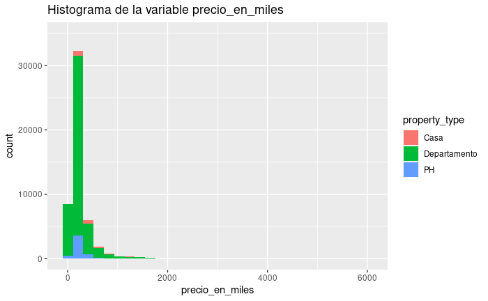

```r
ggplot(datos_limpios, aes(x = precio_en_miles, group = property_type, fill = property_type))+
  geom_histogram() +
  scale_y_continuous(limits = c(0, 35000))+
  ggtitle('Histograma de la variable precio_en_miles')
```

Se puede ver que la gran mayoría de los valores se encuentra entre 0 y 500. Eso podía deducirse también al observar el que el tercer cuartil es 270.

Agrupemos ahora por tipo de propiedad

```r
datos_limpios %>%
  group_by(property_type) %>%
  summarise(Minimo = quantile(precio_en_miles)[1], Q1 = quantile(precio_en_miles)[2], Mediana= quantile(precio_en_miles)[3], Media = mean(precio_en_miles), Q3 = quantile(precio_en_miles)[4], Maximo = quantile(precio_en_miles)[5])
```

| property_type | Minimo | Q1 | Mediana | Media | Q3 | Maximo |
| --- | --- | --- | --- | --- | --- | --- |
| Casa | 20 | 235 | 330.0 | 433.4101 | 490 | 5000 |
| Departamento | 6 | 115 | 164.9 | 247.3604 | 260 | 6000 |
| PH | 32 | 137 | 190.0 | 218.5077 | 270 | 1500 |

Se puede ver que la propiedad de 6 mil dolares era un departamento. Sacando la propiedad de 6 millones de dolares, que también es un departamento, podemos ver que el tipo de propiedad pareciera influir en el precio de la misma: Los valores de los cuartiles en las propiedades de tipo casa son superiores a los valores para los otros tipos de propiedades.

Observemos ahora las diferencias entre los tipos de propiedades mirando los boxplots comparativos

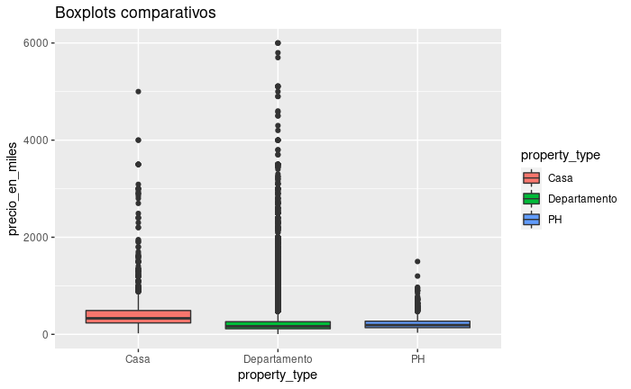

```r
ggplot(datos_limpios, aes(x = property_type,y = precio_en_miles, group = property_type, fill = property_type))+
  geom_boxplot() +
  scale_y_continuous(limits = c(0, 6000))+
  ggtitle('Boxplots comparativos')
```

Seleccionemos ahora los datos numéricos para comparar sus gráficos usando ggpairs.

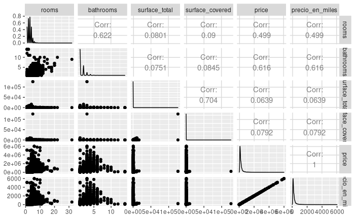

```r
#install.packages('GGally')
library(GGally)
datos_limpios_numericos <- datos_limpios %>%
    select(rooms,bathrooms, surface_total, surface_covered, price, precio_en_miles)

ggpairs(datos_limpios_numericos)
```

Como habíamos visto previamente, no hay mucha correlación entre la variable price y las variables relacionadas a la superficie. Hay bastante correlación con las variables rooms y bathrooms, pero se puede ver en todos los casos que existen valores muy alejados en la parte inferior izquierda de cada gráfico que involucra a price (o a precio_en_miles). El tratamiento de esos outliers se hará en la nueva sección que comenzaremos a continuación.

## Outliers

Veamos más de cerca el gráfico entre precio_en_miles y surface_total

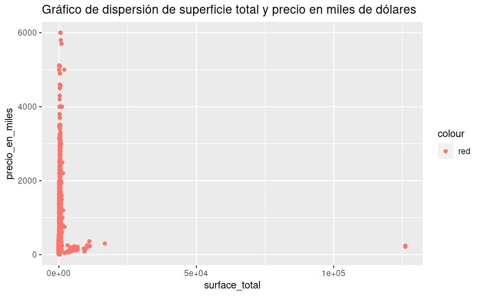

```r
ggplot(datos_limpios, aes(y = precio_en_miles, x = surface_total, color = 'red'))+
  geom_point()+
  ggtitle('Gráfico de dispersión de superficie total y precio en miles de dólares')
```

Se pueden observar muchas propiedades con poca superficie y muy elevado precio, y unas pocas propiedades con muchísima superficie y relativamente bajo precio. Para nuestro análisis podría llegar a convenir remover esas observaciones

Analicemos las variables precio_en_miles, rooms y surface_total. Vamos a remover ooutliers univariados que estén por fuera del intervalo formado por los límites inferior y superior del boxplot, es decir todos los valores que estén por debajo de 1.5 rangos intercuantiles del primer cuartil o aquellos que estén por encima de 1.5 rangos intercuantiles del tercer cuartil.

Recordemos que el entre el primer y tercer cuartil se encuentran la mitad de los datos centrados en la media. Valores muy alejados de dicho intervalo podrían perturbar las relaciones que obtengamos en nuestras variables, lo que en consecuencia deterioraría la performance del modelo lineal. Dado que no vamos a usar un método robusto del modelo lineal, preferimos tomar 1.5 rangos intercuantiles y no 3, donde tendríamos una cantidad mayor de valores atípicos.

```r
datos_rooms <- datos_limpios %>%
  summarise(Variable = 'rooms', Minimo = quantile(rooms)[1], Q1 = quantile(rooms)[2], Mediana= quantile(rooms)[3], Media = mean(rooms), Q3 = quantile(rooms)[4], Maximo = quantile(rooms)[5])

datos_surface_total <- datos_limpios %>%
  summarise(Variable = 'surface_total', Minimo = quantile(surface_total)[1], Q1 = quantile(surface_total)[2], Mediana= quantile(surface_total)[3], Media = mean(surface_total), Q3 = quantile(surface_total)[4], Maximo = quantile(surface_total)[5])

datos_variables <- rbind(datos_precio_en_miles, datos_rooms, datos_surface_total)
datos_variables <- datos_variables %>%
  mutate(IQR = Q3-Q1, liminf = Q1-1.5*IQR, limsup = Q3+1.5*IQR)

datos_variables
```

| Variable | Minimo | Q1 | Mediana | Media | Q3 | Maximo | IQR | liminf | limsup |
| --- | --- | --- | --- | --- | --- | --- | --- | --- | --- |
| precio_en_miles | 6 | 119 | 170 | 251.585209 | 270 | 6000 | 151 | -107.5 | 496.5 |
| rooms | 1 | 2 | 3 | 2.796746 | 4 | 32 | 2 | -1.0 | 7.0 |
| surface_total | 12 | 45 | 66 | 101.751141 | 106 | 126062 | 61 | -46.5 | 197.5 |

Como los valores de estas variables tienen que ser positivos, vamos a filtrar directamente con valores mayores a 0 en vez de usar los límites inferiores que dieron negativo

```r
datos_finales <- datos_limpios %>%
  filter(0 < precio_en_miles, precio_en_miles <= 496.5, 0 < rooms, rooms <= 7, 0 < surface_total, surface_total <= 197.5)
```

## Tercer Análisis exploratorio: nuevo análisis tras remover outliers univariados

Analicemos las tres variables en las que nos centramos en la sección anterior ahora que quitamos outliers

```r
datos_precio_en_miles2 <- datos_finales %>%
  summarise(Variable = 'precio_en_miles', Minimo = quantile(precio_en_miles)[1], Q1 = quantile(precio_en_miles)[2], Mediana= quantile(precio_en_miles)[3], Media = mean(precio_en_miles), Q3 = quantile(precio_en_miles)[4], Maximo = quantile(precio_en_miles)[5])

datos_rooms2 <-  datos_finales %>%
  summarise(Variable = 'rooms', Minimo = quantile(rooms)[1], Q1 = quantile(rooms)[2], Mediana= quantile(rooms)[3], Media = mean(rooms), Q3 = quantile(rooms)[4], Maximo = quantile(rooms)[5])

datos_surface_total2 <-  datos_finales %>%
  summarise(Variable = 'surface_total', Minimo = quantile(surface_total)[1], Q1 = quantile(surface_total)[2], Mediana= quantile(surface_total)[3], Media = mean(surface_total), Q3 = quantile(surface_total)[4], Maximo = quantile(surface_total)[5])

datos_variables2 <- rbind(datos_precio_en_miles2, datos_rooms2, datos_surface_total2)
datos_variables2 <- datos_variables2 %>%
  mutate(IQR = Q3-Q1, liminf = Q1-1.5*IQR, limsup = Q3+1.5*IQR)

datos_variables2
```

| Variable | Minimo | Q1 | Mediana | Media | Q3 | Maximo | IQR | liminf | limsup |
| --- | --- | --- | --- | --- | --- | --- | --- | --- | --- |
| precio_en_miles | 7.5 | 113 | 157 | 182.210773 | 230 | 496 | 117 | -62.5 | 405.5 |
| rooms | 1.0 | 2 | 2 | 2.538012 | 3 | 7 | 1 | 0.5 | 4.5 |
| surface_total | 12.0 | 43 | 60 | 70.203170 | 87 | 197 | 44 | -23.0 | 153.0 |

Realicemos el análisis en precio en miles separando nuevamente por tipo de propiedad

```r
datos_finales %>%
  group_by(property_type) %>%
  summarise(Minimo = quantile(precio_en_miles)[1], Q1 = quantile(precio_en_miles)[2], Mediana= quantile(precio_en_miles)[3], Media = mean(precio_en_miles), Q3 = quantile(precio_en_miles)[4], Maximo = quantile(precio_en_miles)[5])
```

| property_type | Minimo | Q1 | Mediana | Media | Q3 | Maximo |
| --- | --- | --- | --- | --- | --- | --- |
| Casa | 20.0 | 175 | 236.500 | 241.0795 | 299 | 492 |
| Departamento | 7.5 | 110 | 154.401 | 179.9369 | 229 | 496 |
| PH | 32.0 | 130 | 175.000 | 193.2357 | 249 | 490 |

Veamos ahora como quedo el histograma de la variable precio_en_miles tras quitar outliers

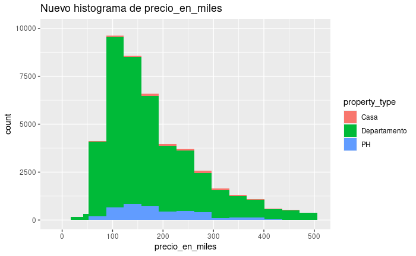

```r
ggplot(datos_finales, aes(x = precio_en_miles, group = property_type, fill = property_type))+
  geom_histogram() +
  stat_bin(bins = 15)+
  scale_y_continuous(limits = c(0, 10000))+
  ggtitle('Nuevo histograma de precio_en_miles')
```

Al quitar los valores por encima de 500, que nos ocupaban más del 90% del espacio horizontal, nuestro histograma luce mucho más comprensible. Se puede ver además que a el descenso de casos al tomar un bin más a la derecha es bastante gradual, por lo que podemos asumir que los outliers que tenemos ahora son provenientes, en su gran mayoría, de datos reales.

Veamos ahora el gráfico de pares tras remover outliers

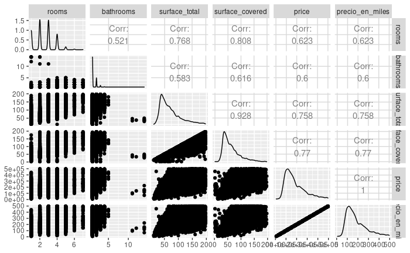

```r
datos_finales_numericos <- datos_finales %>%
    select(rooms,bathrooms, surface_total, surface_covered, price, precio_en_miles)

ggpairs(datos_finales_numericos)
```

A simple vista notamos que, tras extraer outliers univariados, la correlación entre las variables de superficie con las variables de precio subió exponencialmente (casi 10 veces). A la variable bathrooms no le hicimos un tratamiento de outliers y por ende se puede ver que los gráficos de pares que conciernen a esa variable están un poco desbalanceados.

## Modelo Lineal

En esta sección vamos a realizar modelos lineales para intentar explicar la relación entre el precio de las propiedades, medido en miles de dólares, y otras variables de nuestro dataset.

Vamos a comenzar analizando precio_en_miles en funcion de la variable rooms

```r
modelo_rooms <- lm(formula = precio_en_miles ~ rooms, data = datos_finales)

summary(modelo_rooms)
```

```
Call:
lm(formula = precio_en_miles ~ rooms, data = datos_finales)

Residuals:
    Min      1Q  Median      3Q     Max
-270.94  -46.37  -11.08   31.35  340.92

Coefficients:
            Estimate Std. Error t value Pr(>|t|)
(Intercept)  49.5065     0.8587   57.65   <2e-16 ***
rooms        52.2867     0.3103  168.53   <2e-16 ***
---
Signif. codes:  0 ‘***’ 0.001 ‘**’ 0.01 ‘*’ 0.05 ‘.’ 0.1 ‘ ’ 1

Residual standard error: 72.56 on 44852 degrees of freedom
Multiple R-squared:  0.3877,    Adjusted R-squared:  0.3877
F-statistic: 2.84e+04 on 1 and 44852 DF,  p-value: < 2.2e-16
```

Lo que podemos interpretar de este modelo es que podemos estimar el valor de una propiedad en miles de dólares multiplicando 52.29 por el total de habitaciónes y a eso sumarle 49.51. De esto podemos deducir que una propiedad costaría en promedio un poco más de 50 mil dólares que otra propiedad que tenga una habitación menos.

Se puede ver además que el p-valor es muy pequeño, por ende la relación entre el precio en miles de dólares y la variable rooms es estadísticamente significativa.

Veamos ahora el intervalo de confianza usando la librería tidymodels

```r
#install.packages('tidymodels')
library(tidymodels)
tidy(modelo_rooms, conf.int = T, conf.level = 0.95)
```

| term | estimate | std.error | statistic | p.value | conf.low | conf.high |
| --- | --- | --- | --- | --- | --- | --- |
| (Intercept) | 49.50654 | 0.8587476 | 57.6497 | 0 | 47.82338 | 51.18970 |
| rooms | 52.28668 | 0.3102563 | 168.5274 | 0 | 51.67857 | 52.89479 |

Como se puede ver, el intervalo de confianza de la pendiente está muy lejos de contener al 0.

Para obtener una mejor interpretación realicemos un gráfico

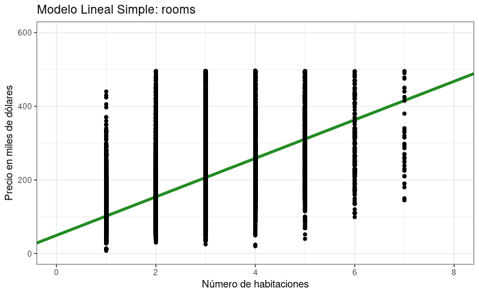

```r
datos_finales %>% ggplot(., aes(x = rooms, y = precio_en_miles)) +
  geom_abline(intercept = modelo_rooms$coefficients[1], slope = modelo_rooms$coefficients[2], color="forestgreen", size=1.5) +
  geom_point() +
  theme_bw() +
  scale_x_continuous(limits = c(0,8)) +
  scale_y_continuous(limits = c(0,600)) +
  labs(title="Modelo Lineal Simple: rooms", x="Número de habitaciones", y="Precio en miles de dólares")
```

A nuestro criterio, y a partir de lo que se ve en este gráfico, este modelo resulta ser bastante sesgado. Analicemos la validación de los supuestos

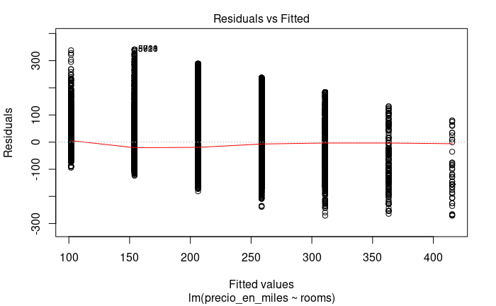

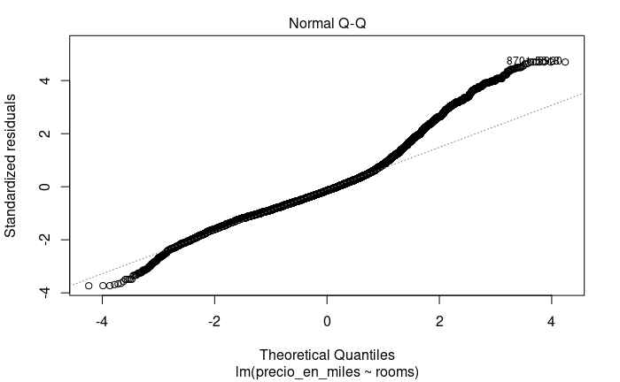

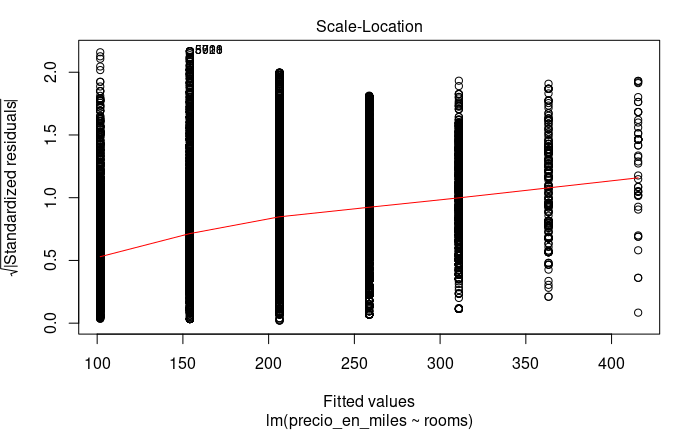

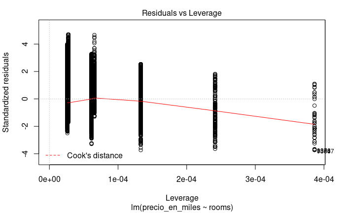

```r
plot(modelo_rooms)
```

```r
cor.test(datos_finales$precio_en_miles, datos_finales$rooms, method = "pearson")
```

```
    Pearson's product-moment correlation

data:  datos_finales$precio_en_miles and datos_finales$rooms
t = 168.53, df = 44852, p-value < 2.2e-16
alternative hypothesis: true correlation is not equal to 0
95 percent confidence interval:
 0.6169685 0.6283016
sample estimates:
      cor
0.6226677
```

Tenemos evidencia significativa de que las variables se correlacionan. Veamos ahora el modelo poniendo el precio en miles de dólares en función de la variable surface_total

```r
modelo_surface <- lm(formula = precio_en_miles ~ surface_total, data = datos_finales)

summary(modelo_surface)
```

```
Call:
lm(formula = precio_en_miles ~ surface_total, data = datos_finales)

Residuals:
    Min      1Q  Median      3Q     Max
-325.52  -31.71   -8.28   25.33  370.73

Coefficients:
               Estimate Std. Error t value Pr(>|t|)
(Intercept)   44.541192   0.628348   70.89   <2e-16 ***
surface_total  1.961017   0.007972  245.99   <2e-16 ***
---
Signif. codes:  0 ‘***’ 0.001 ‘**’ 0.01 ‘*’ 0.05 ‘.’ 0.1 ‘ ’ 1

Residual standard error: 60.5 on 44852 degrees of freedom
Multiple R-squared:  0.5743,    Adjusted R-squared:  0.5743
F-statistic: 6.051e+04 on 1 and 44852 DF,  p-value: < 2.2e-16
```

Se puede ver que cada metro cuadrado extra agrega en promedio alrededor de 2000 dolares más al precio de una propiedad. Veamos los intervalos de confianza y grafiquemos el modelo

```r
tidy(modelo_surface, conf.int = T, conf.level = 0.95)
```

| term | estimate | std.error | statistic | p.value | conf.low | conf.high |
| --- | --- | --- | --- | --- | --- | --- |
| (Intercept) | 44.541192 | 0.628348402 | 70.88614 | 0 | 43.309619 | 45.772766 |
| surface_total | 1.961017 | 0.007971818 | 245.99365 | 0 | 1.945392 | 1.976641 |

Nuevamente, el intervalo correspondiende a la pendiente no contiene al 0.

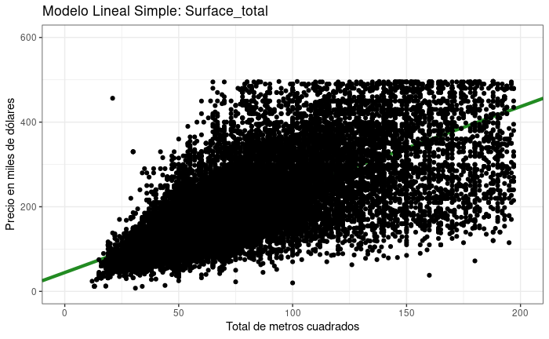

```r
datos_finales %>% ggplot(., aes(x = surface_total, y = precio_en_miles)) +
  geom_abline(intercept = modelo_surface$coefficients[1], slope = modelo_surface$coefficients[2], color="forestgreen", size=1.5) +
  geom_point() +
  theme_bw() +
  scale_x_continuous(limits = c(0,200)) +
  scale_y_continuous(limits = c(0,600)) +
  labs(title="Modelo Lineal Simple: Surface_total", x="Total de metros cuadrados", y="Precio en miles de dólares")
```

Este modelo también tiene sesgo y pareciera que los errores no son homocédasticos: a más metros cuadrados mayor es el error del modelo. Análicemos la validación de los supuestos

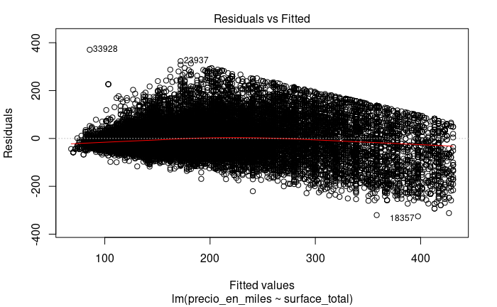

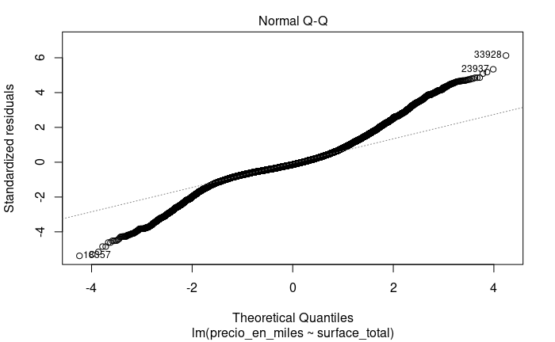

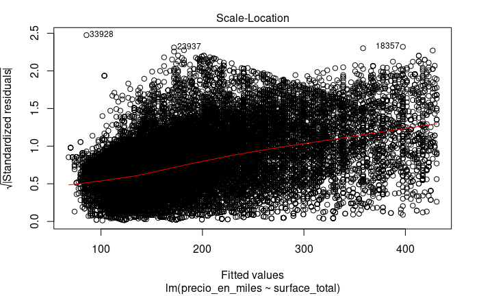

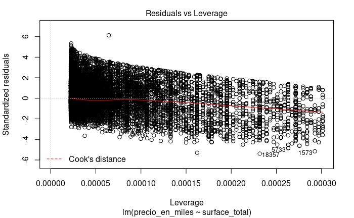

```r
plot(modelo_surface)
```

```r
cor.test(datos_finales$precio_en_miles, datos_finales$surface_total, method = "pearson")
```

```
    Pearson's product-moment correlation

data:  datos_finales$precio_en_miles and datos_finales$surface_total
t = 245.99, df = 44852, p-value < 2.2e-16
alternative hypothesis: true correlation is not equal to 0
95 percent confidence interval:
 0.7538700 0.7617493
sample estimates:
      cor
0.7578373
```

Para terminar de decidir por un modelo, vamos a comparar los coeficientes R².

El error cuadrado múltiple del modelo de rooms es 0.3877, mientras que el del modelo de superficie total es 0.5743. Esto significa que el modelo de regresión basado en la superficie total en metros cuadrados tiene más capacidad para predecir el precio de la propiedad. Vamos a echarle un vistazo más a cada modelo usando la función glance del paquete broom.

```r
glance(modelo_rooms)
```

| r.squared | adj.r.squared | sigma | statistic | p.value | df | logLik | AIC | BIC | deviance | df.residual | nobs |
| --- | --- | --- | --- | --- | --- | --- | --- | --- | --- | --- | --- |
| 0.3877151 | 0.3877014 | 72.56462 | 28401.48 | 0 | 1 | -255820 | 511646 | 511672.2 | 236173781 | 44852 | 44854 |

```r
glance(modelo_surface)
```

| r.squared | adj.r.squared | sigma | statistic | p.value | df | logLik | AIC | BIC | deviance | df.residual | nobs |
| --- | --- | --- | --- | --- | --- | --- | --- | --- | --- | --- | --- |
| 0.5743174 | 0.5743079 | 60.50498 | 60512.88 | 0 | 1 | -247667.7 | 495341.5 | 495367.6 | 164196562 | 44852 | 44854 |

## Conclusión final

Basándonos en el mayor valor del coeficiente R² y en nuestra observación de los gráficos de los modelos, concluimos que el modelo donde utilizamos la superficie total es mejor para predecir y explicar el precio en miles de dólares de las propiedades.